# DATS6101 Group Project: Cardiovascular Disease

Chia Han Lee, Jingya Gao, Xiaotian Huang, and Xinyu Yao

Oct 22, 2019

## Chapter 1: Introduction of Cardiovascular Disease:

Based on The World Health Organization (WHO), Cardiovascular diseases (CVDs) are disorders related to the heart and blood vessels. The diseases mainly caused by fatty deposits plaque builds up on the inner walls of the blood vessels which prevent prevents blood from flowing to the heart or brain.

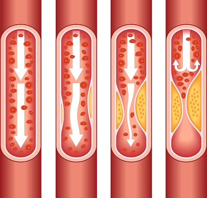

The process of fatty plaque formation.

According to 2016 report, cardiovascular disease remains the leading cause of death in the United States (Benjamin et al., 2019). Around 80% of CVD deaths are a heart attack and stroke. The cause of cardiovascular diseases is usually the presence of a combination of risk factors, such as unhealthy diet, obesity, physical inactivity, tobacco use and harmful use of alcohol.

Body mass index (BMI) is a value calculated from the weight and height of a person, the equation is kg(kilogram)/m(meter)^2. It is a measurement to assess a person’s total amount of body fat. As measuring BMI only needs a person’s weight and height, it has been widely used in public health and clinical settings.

Since there are many reports indicated that the cause of cardiovascular diseases is associated with our BMI and lifestyle. Therefore, we want to evaluate whether these factors truly correlate with the developing of the disease.

## Chapter 2: Description of Data and Exploratory Data Analysis

### 2.1 Source Data

The source data for our EDA is a CSV containing 70 000 records of patients data in 12 features: age, height, weight, gender, systolic blood pressure, diastolic blood pressure, cholesterol, glucose, smoking, alcohol intake, physical activity, and presence or absence of cardiovascular disease. (https://www.kaggle.com/sulianova/cardiovascular-disease-dataset)

```
## 'data.frame':    70000 obs. of  13 variables:
##  $ id         : int  0 1 2 3 4 8 9 12 13 14 ...
##  $ age        : int  18393 20228 18857 17623 17474 21914 22113 22584 17668 19834 ...
##  $ gender     : Factor w/ 2 levels "1","2": 2 1 1 2 1 1 1 2 1 1 ...
##  $ height     : int  168 156 165 169 156 151 157 178 158 164 ...
##  $ weight     : num  62 85 64 82 56 67 93 95 71 68 ...
##  $ ap_hi      : int  110 140 130 150 100 120 130 130 110 110 ...
##  $ ap_lo      : int  80 90 70 100 60 80 80 90 70 60 ...
##  $ cholesterol: Factor w/ 3 levels "1","2","3": 1 3 3 1 1 2 3 3 1 1 ...
##  $ gluc       : Factor w/ 3 levels "1","2","3": 1 1 1 1 1 2 1 3 1 1 ...
##  $ smoke      : Factor w/ 2 levels "0","1": 1 1 1 1 1 1 1 1 1 1 ...
##  $ alco       : Factor w/ 2 levels "0","1": 1 1 1 1 1 1 1 1 1 1 ...
##  $ active     : Factor w/ 2 levels "0","1": 2 2 1 2 1 1 2 2 2 1 ...
##  $ cardio     : Factor w/ 2 levels "0","1": 1 2 2 2 1 1 1 2 1 1 ...
```

### 2.2 Preprocessing Data

We noticed that variable ‘age’ is int(day), which were converted into int(years).As height and weight individually do not mean much to patients’ health, so we calculated Body Mass Index (BMI), a measure of body fat based on height and weight that applies to adult men and women, and added it as a feature. Also column ‘id’ was droped.

```
##       age        gender        height          weight
##  Min.   :30.00   1:45530   Min.   : 55.0   Min.   : 10.00
##  1st Qu.:48.00   2:24470   1st Qu.:159.0   1st Qu.: 65.00
##  Median :54.00             Median :165.0   Median : 72.00
##  Mean   :53.34             Mean   :164.4   Mean   : 74.21
##  3rd Qu.:58.00             3rd Qu.:170.0   3rd Qu.: 82.00
##  Max.   :65.00             Max.   :250.0   Max.   :200.00
##      ap_hi             ap_lo          cholesterol gluc      smoke
##  Min.   : -150.0   Min.   :  -70.00   1:52385     1:59479   0:63831
##  1st Qu.:  120.0   1st Qu.:   80.00   2: 9549     2: 5190   1: 6169
##  Median :  120.0   Median :   80.00   3: 8066     3: 5331
##  Mean   :  128.8   Mean   :   96.63
##  3rd Qu.:  140.0   3rd Qu.:   90.00
##  Max.   :16020.0   Max.   :11000.00
##  alco      active    cardio         bmi
##  0:66236   0:13739   0:35021   Min.   :  3.472
##  1: 3764   1:56261   1:34979   1st Qu.: 23.875
##                                Median : 26.374
##                                Mean   : 27.557
##                                3rd Qu.: 30.222
##                                Max.   :298.667
```

We noticed that the min value of systolic blood pressure(ap_hi) and diastolic blood pressure (ap_lo) are negative values, which do not make sense. In addition, diastolic blood pressure is supposed to be lower than systolic blood pressure. The data were further cleaned based on these crterion.

Then the distribution of age, height, weight, ap_hi and ap_lo was checked.

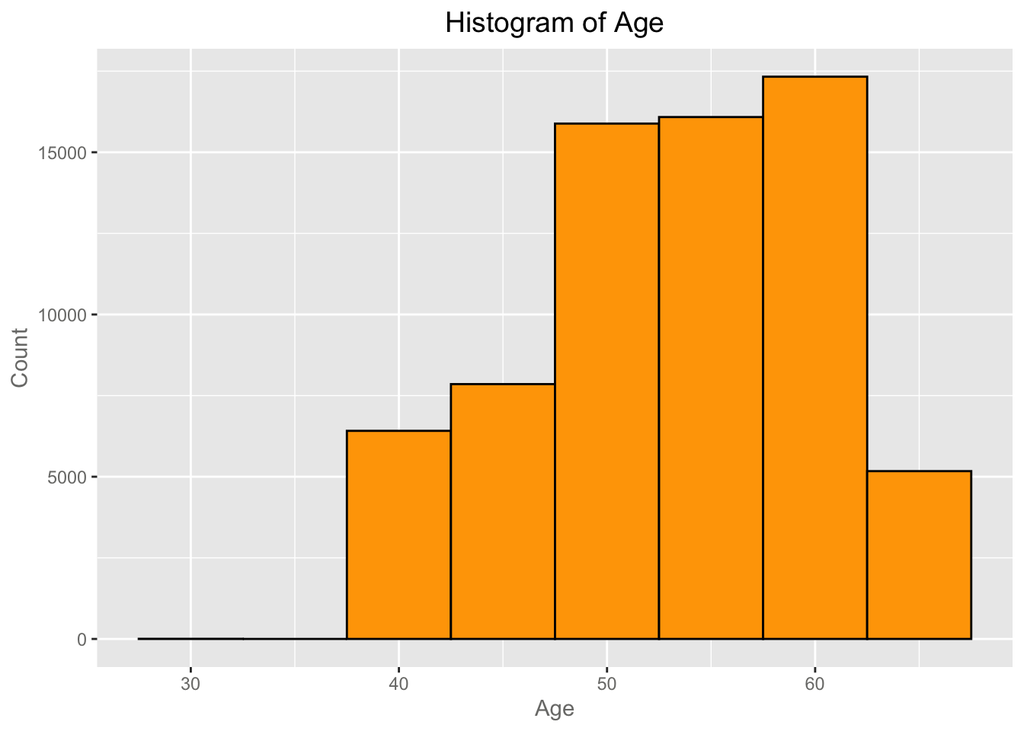

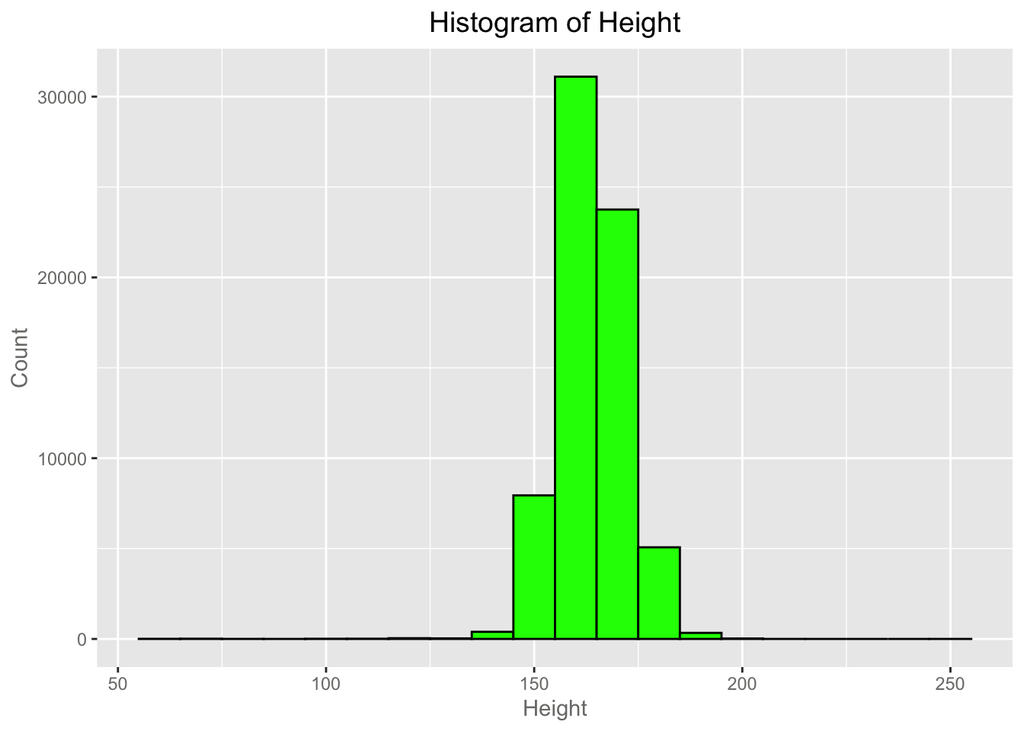

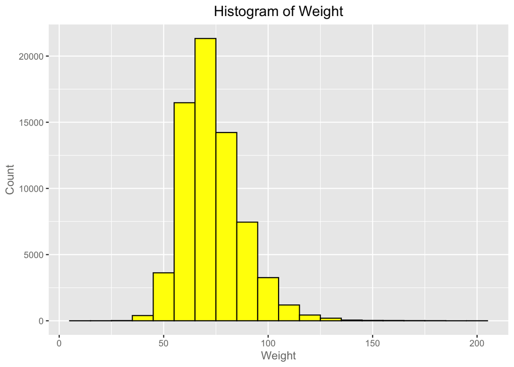

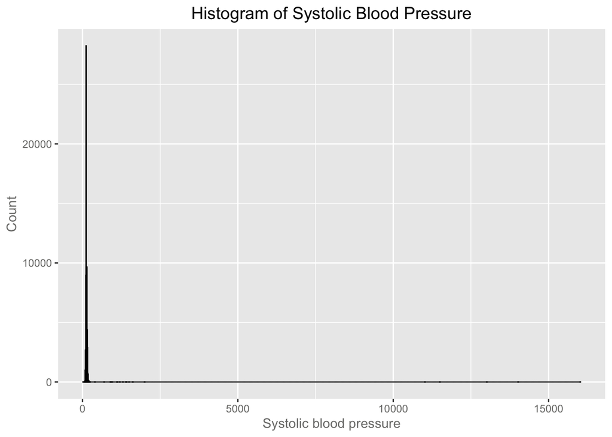

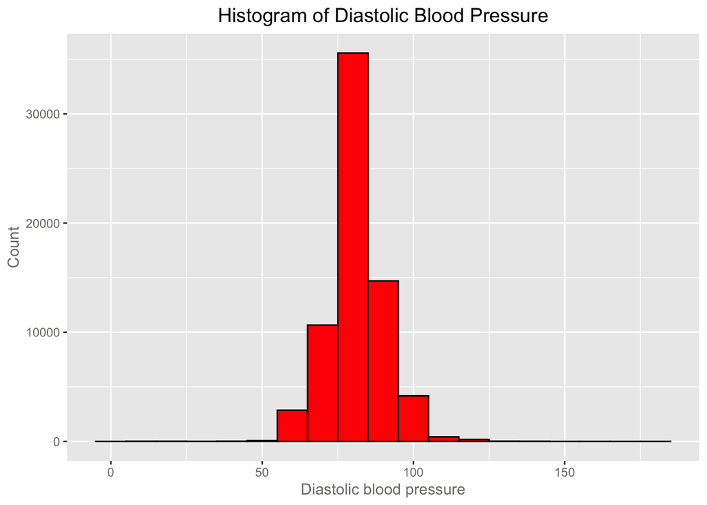

The histogram of age shows that there are only few observation for age<35, which could not represent the population of age<35, so the observations with age<35 were droped. For height, weight, ap_hi, and ap_lo, the histograms were way skewed by some extreme outliers, which were droped in this step.

The distribution of age, height, weight, ap_hi and ap_lo was checked again after outliers removed.

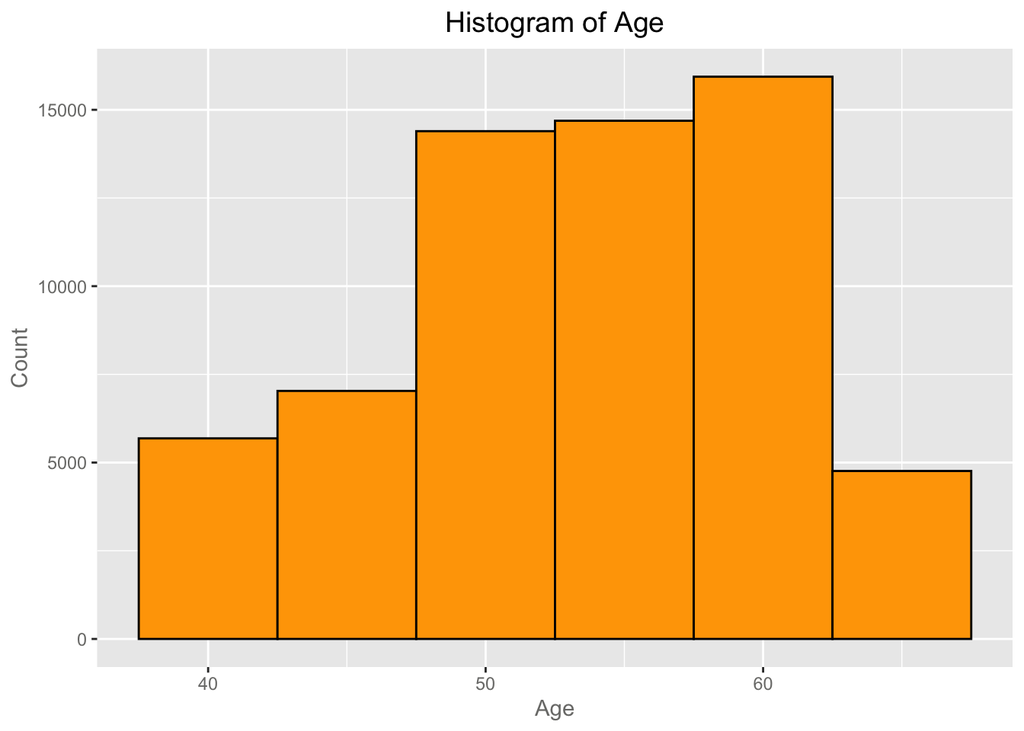

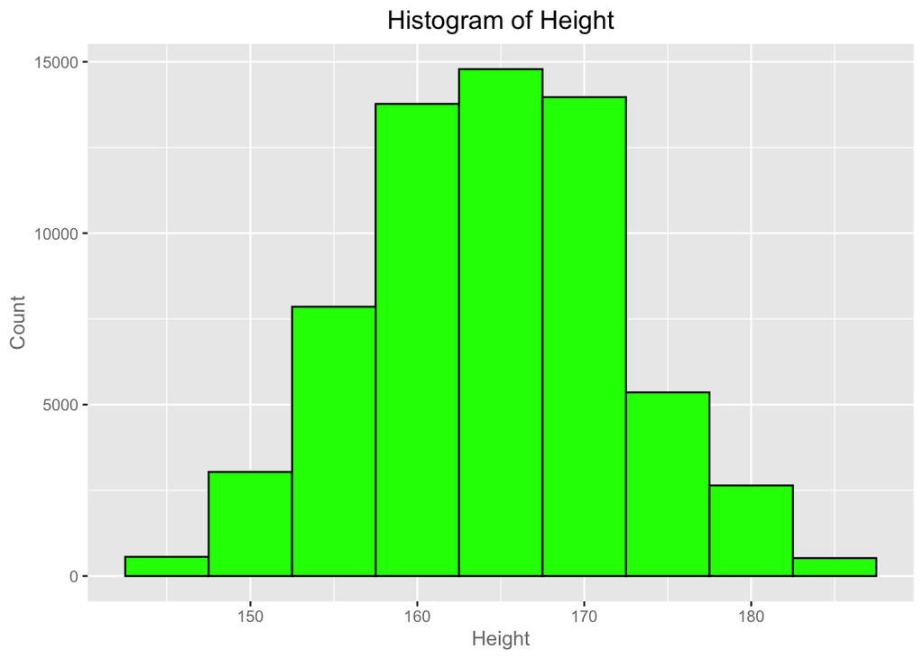

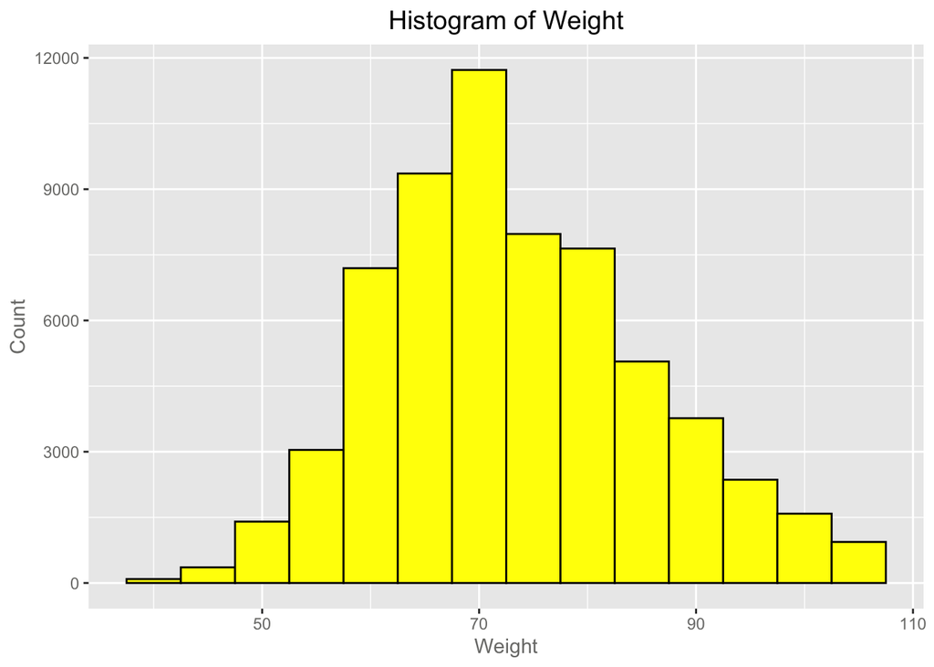

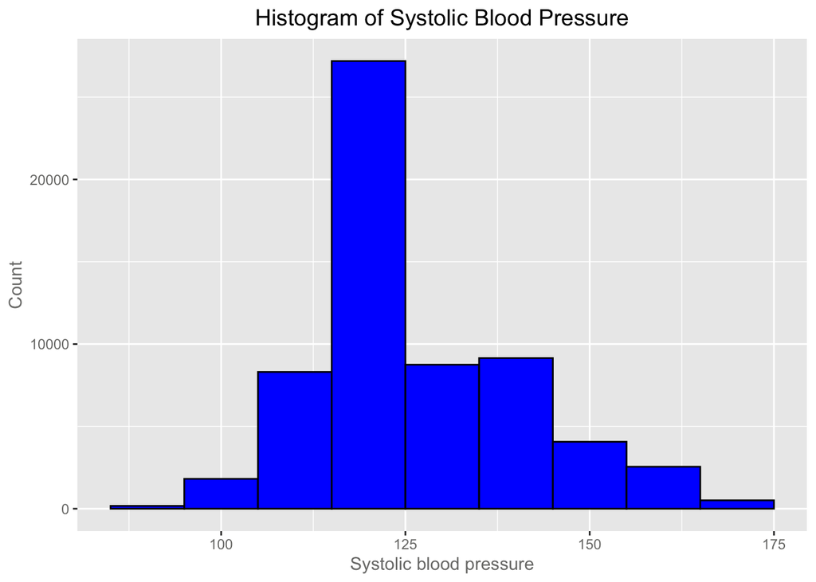

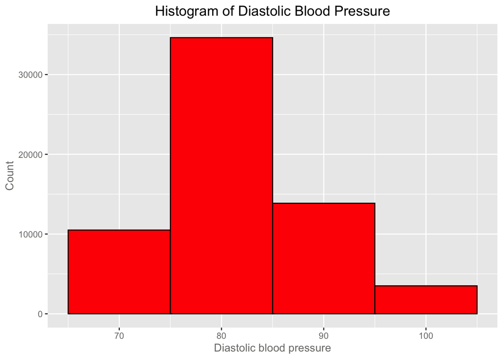

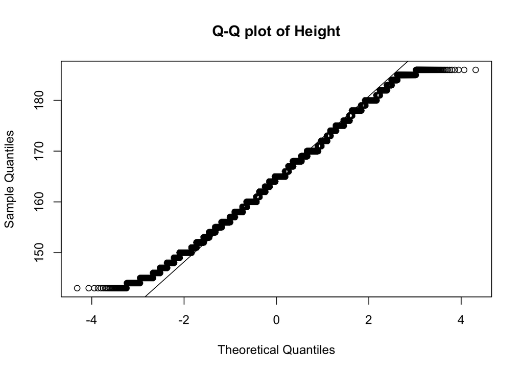

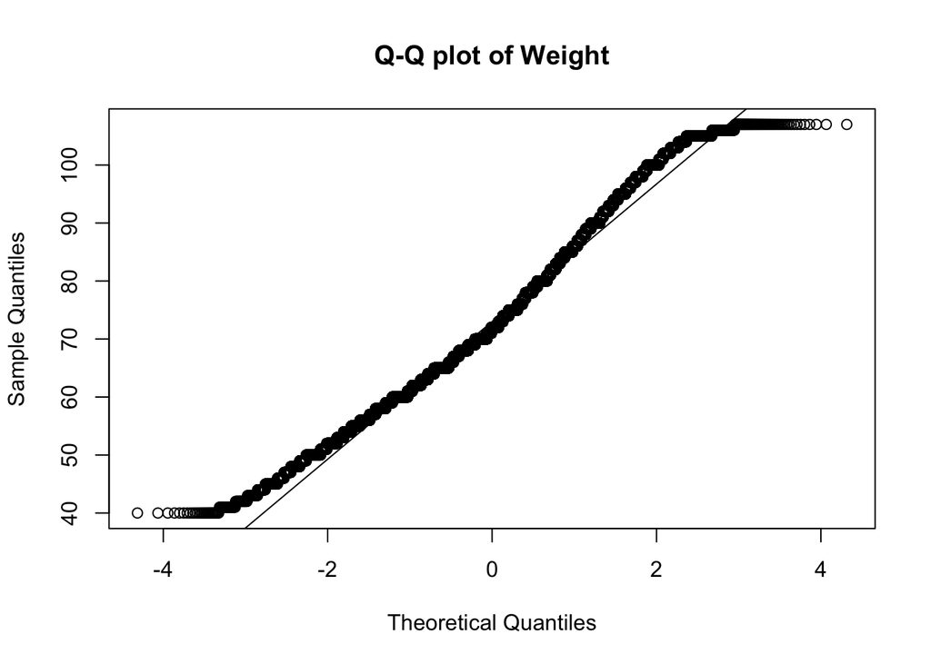

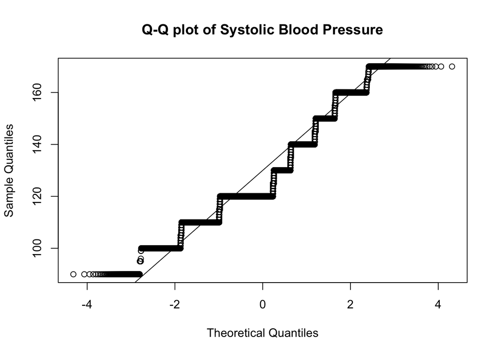

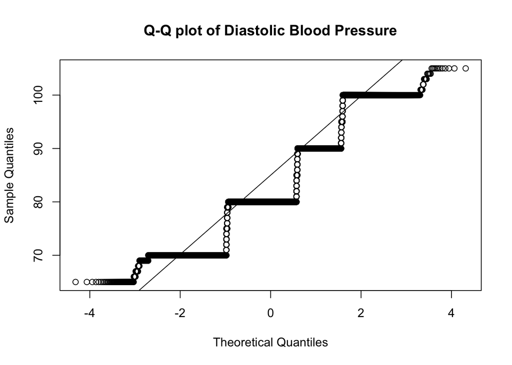

### 2.3 Correlations among Different Variables

The correlation matrix was displayed to get an idea of the correlations among different variables.

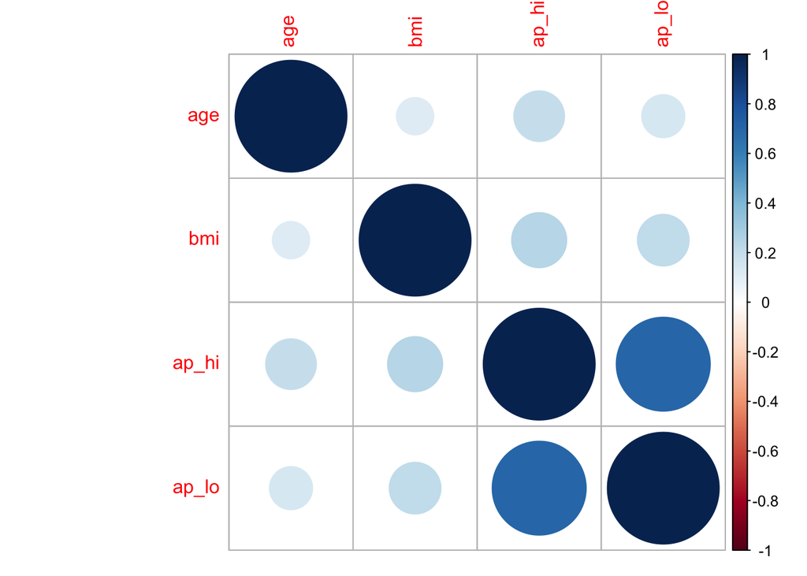

## Chapter 3: Cardio

### 3.1 SMART Question

What are the risk factors of cardiovascular diseases? Is gender, BMI, cholesterol level, glucose level, smoking, alcohol over-consumption and lack of exercise correlated to the development of cardiovascular disease?

### 3.2 Basic analyze

First, we categorize BMI values into 5 groups, starting from numerical value ranging (1-10), and then add the numerical value by 10, sequentially. Chi-square test is being used as the preferred method, as it shows the correlation between cardiovascular disease and BMI, age, cholesterol level, glucose level, smoking behavior, alcohol over-consumption, and lack of exercise.

```
##
##  Pearson's Chi-squared test
##
## data:  cardio_bmi
## X-squared = 1546.2, df = 4, p-value < 2.2e-16
```

```
##
##  Pearson's Chi-squared test
##
## data:  cardio_glucose
## X-squared = 476.48, df = 2, p-value < 2.2e-16
```

```
##
##  Pearson's Chi-squared test with Yates' continuity correction
##
## data:  cardio_smoke
## X-squared = 30.402, df = 1, p-value = 3.511e-08
```

```
##
##  Pearson's Chi-squared test with Yates' continuity correction
##
## data:  cardio_alco
## X-squared = 9.4869, df = 1, p-value = 0.002069
```

```
##
##  Pearson's Chi-squared test with Yates' continuity correction
##
## data:  cardio_active
## X-squared = 88.188, df = 1, p-value < 2.2e-16
```

```
##
##  Pearson's Chi-squared test
##
## data:  cardio_age
## X-squared = 2974.3, df = 3, p-value < 2.2e-16
```

```
##
##  Pearson's Chi-squared test
##
## data:  cardio_cholesterol
## X-squared = 2976.9, df = 2, p-value < 2.2e-16
```

The null hypothesis is rejected as all p-values are small. All factors indicated above are considered to be risk factors of cardiovascular disease.

In addition to Chapter 2, a bar plot is generated to show the relationship between age and the onset of cardiovascular disease.

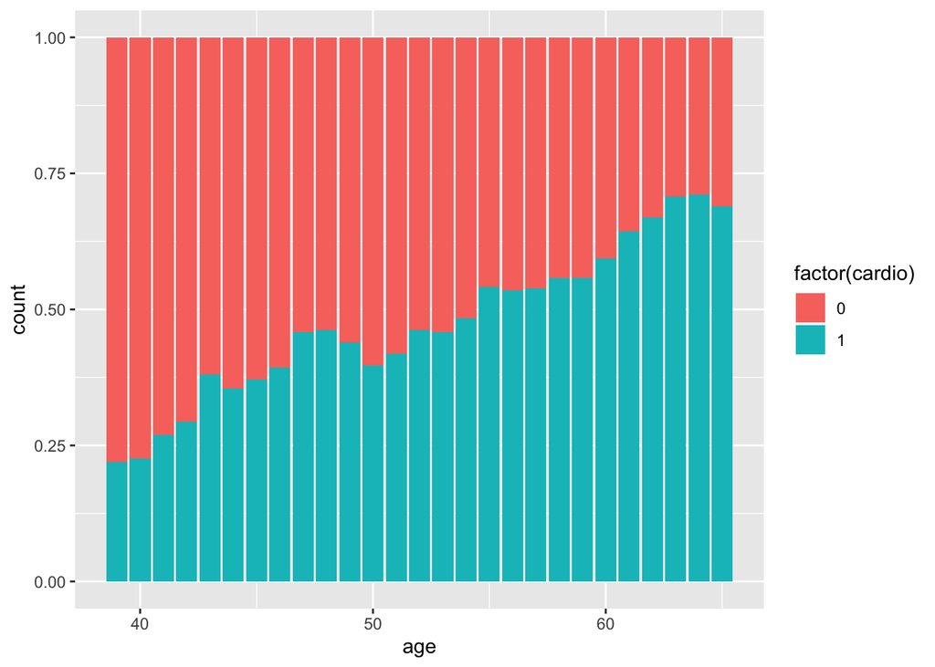

As the bar plot shows, the number of elderly with cardiovascular disease is higher than the number of younger people with cardiovascular disease. We will discuss how age may affect cardiovascular disease in further detail in Chapter 5.

## Chapter 4: BMI

### 4.1 SMART Question

What is the relationship between BMI and cardiovascular diseas and what factors will affect bmi?

### 4.2 Is that bmi affect cardiovascular disease?

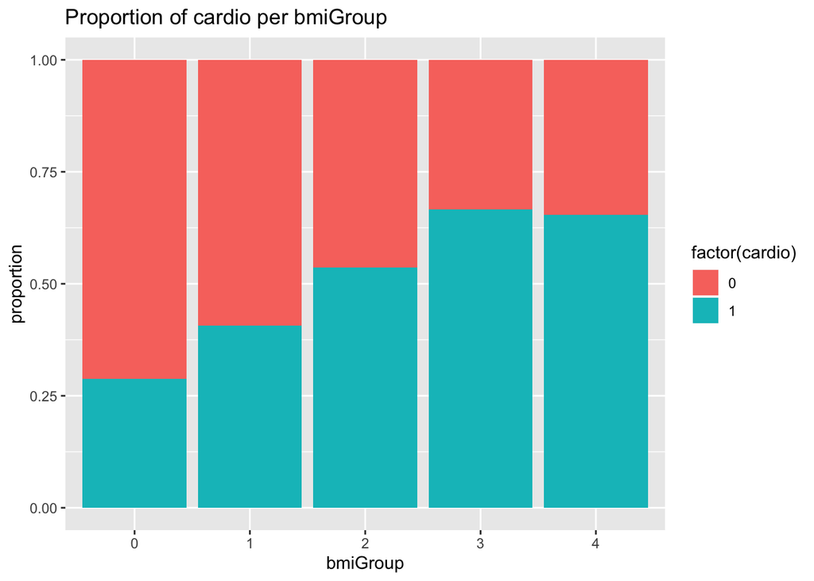

By comparing the BMI group with the incidence of getting cardiovascular disease, we conclude that people with higher BMI are more likely to develop cardiovascular disease. Likewise, people with cardiovascular disease are also more likely to have higher BMI.

In addition, we subset cardiovascular disease group, with [cardio0] for people without cardiovascular disease and [cardio1] for people with cardiovascular disease. Then, we compare the mean and histogram between people with cardiovascular disease and without cardiovascular disease.

```
## [1] 26.31278
```

```
## [1] 27.94742
```

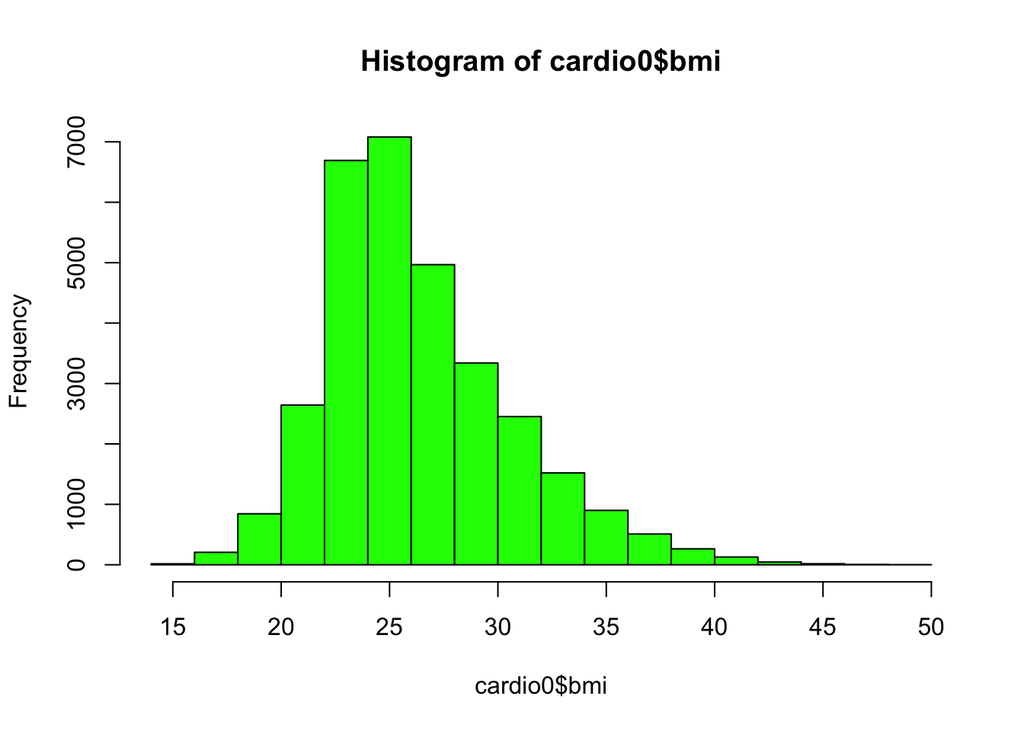

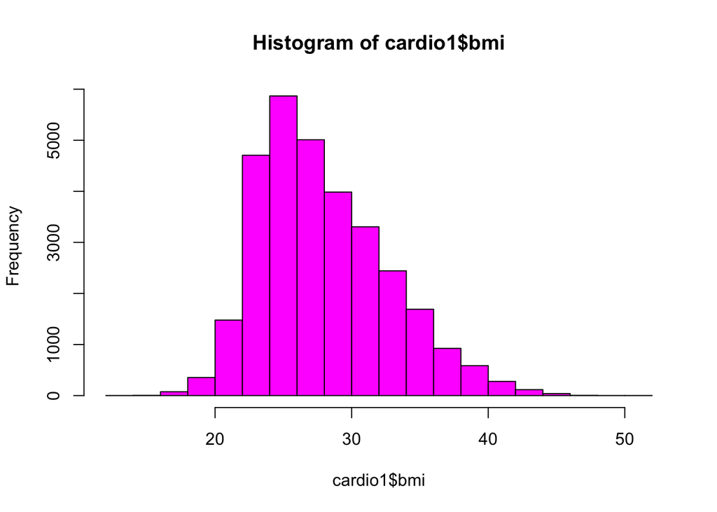

From both mean and histogram, we observe that people with cardiovascular diseases tend to have higher BMI than people without cardiovascular diseases. We conclude BMI and cardiovascular have correlation.

We will go on with the hypothesis that risk factors of high BMI value will also be the risk factors of cardiovascular diseases.

### 4.3 Basic analysis of BMIgroup

We fisrt use chi-test to see the relationship between BMIgroup and glucose, smoke, alchol level, exercise.

```
##
##  Pearson's Chi-squared test
##
## data:  bmi_glucose
## X-squared = 637.17, df = 8, p-value < 2.2e-16
```

```
##
##  Pearson's Chi-squared test
##
## data:  bmi_smoke
## X-squared = 124.54, df = 4, p-value < 2.2e-16
```

```
##
##  Pearson's Chi-squared test
##
## data:  bmi_alco
## X-squared = 53.676, df = 4, p-value = 6.153e-11
```

```
##
##  Pearson's Chi-squared test
##
## data:  bmi_active
## X-squared = 8.5446, df = 4, p-value = 0.07355
```

In addition, the analysis indicates BMI level is associated with the presence of cardiovascular disease. Smoking behavior, alcohol-consumption, and glucose level are also associated with the onset of cardiovascular disease.

Furthermore, we fail to reject H0 as the p-value for activity level is greater than 0.05. There is no impact on BMI among people who are active and people who are not active.

### 4.4 Conclusion of BMI

We use t-test and boxplot to analyze BMI and subset each risk factors. Specifically, we subset women and men for gender, smoke (0) and not smoke (1) for smoking behavior, noalco (0) and alco (1) for alcohol consumption, and noactive (0) and active (1) for activity level. Boxplot helps us to find groups with higher BMI.

```
##
##  Welch Two Sample t-test
##
## data:  cardio0$bmi and cardio1$bmi
## t = -45.412, df = 61629, p-value < 2.2e-16
## alternative hypothesis: true difference in means is not equal to 0
## 95 percent confidence interval:
##  -1.705197 -1.564092
## sample estimates:
## mean of x mean of y
##  26.31278  27.94742
```

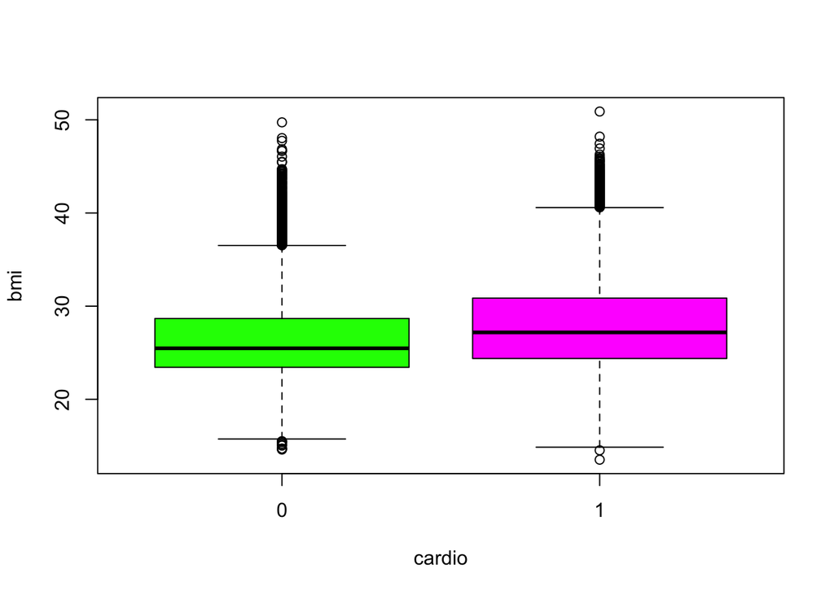

```
##
##  Welch Two Sample t-test
##
## data:  women$bmi and men$bmi
## t = 36.099, df = 55336, p-value < 2.2e-16
## alternative hypothesis: true difference in means is not equal to 0
## 95 percent confidence interval:
##  1.196799 1.334223
## sample estimates:
## mean of x mean of y
##  27.56122  26.29571
```

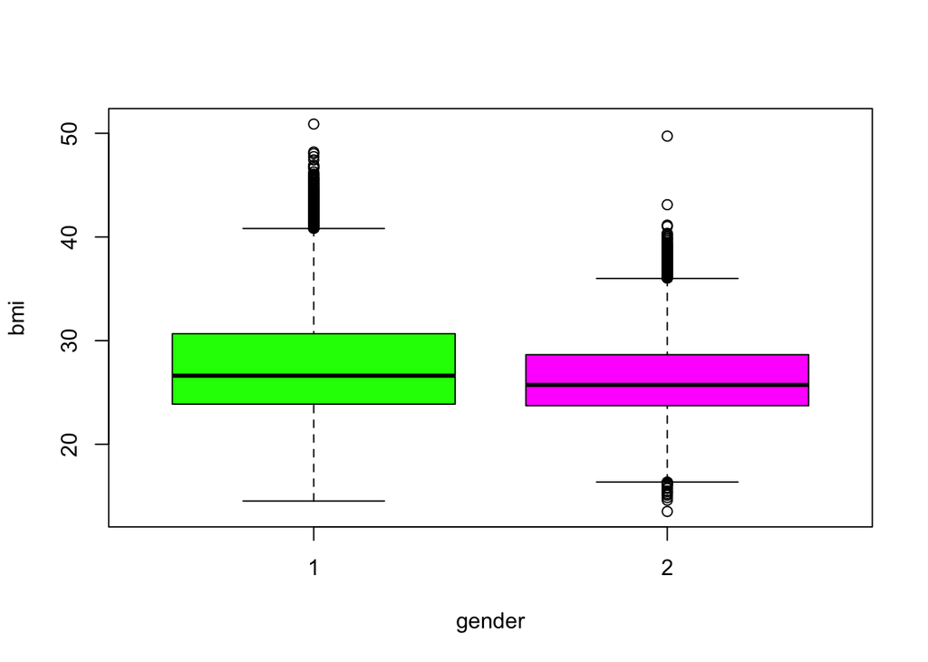

```
##
##  Welch Two Sample t-test
##
## data:  not_smoke$bmi and smoke$bmi
## t = 11.943, df = 6773.2, p-value < 2.2e-16
## alternative hypothesis: true difference in means is not equal to 0
## 95 percent confidence interval:
##  0.5853395 0.8152236
## sample estimates:
## mean of x mean of y
##  27.18058  26.48030
```

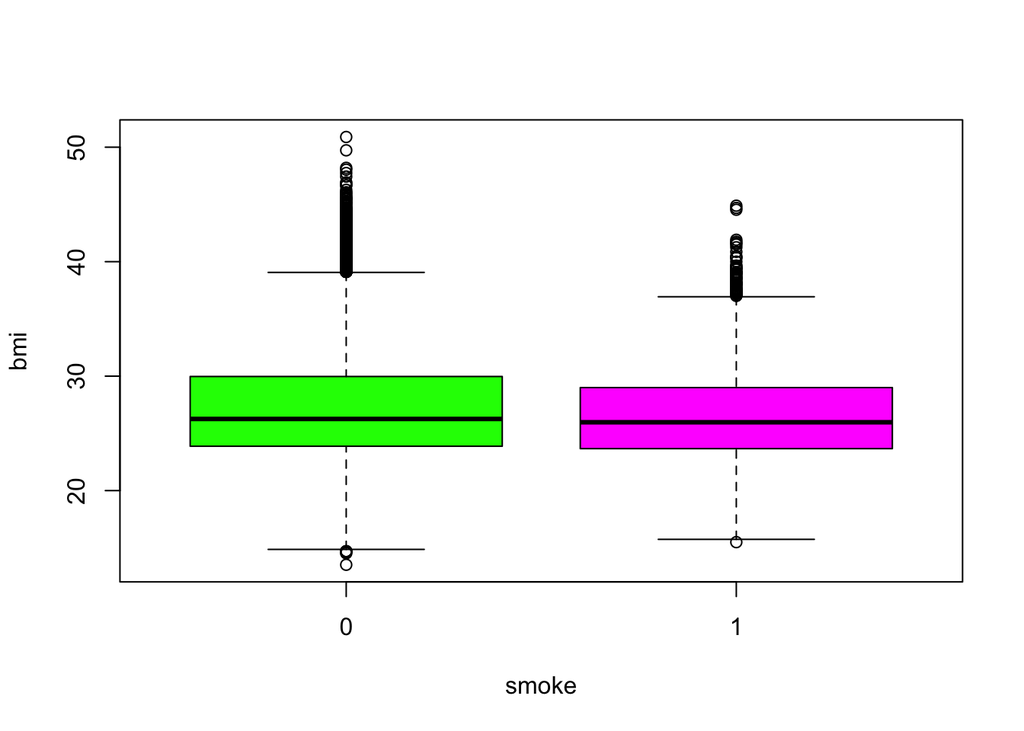

```
##
##  Welch Two Sample t-test
##
## data:  noalco$bmi and alco$bmi
## t = -2.8869, df = 3647, p-value = 0.003914
## alternative hypothesis: true difference in means is not equal to 0
## 95 percent confidence interval:
##  -0.38919138 -0.07436675
## sample estimates:
## mean of x mean of y
##  27.10803  27.33981
```

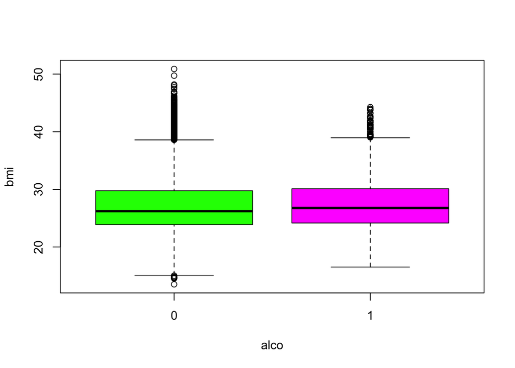

```
##
##  Welch Two Sample t-test
##
## data:  noactive$bmi and active$bmi
## t = 2.1267, df = 18396, p-value = 0.03346
## alternative hypothesis: true difference in means is not equal to 0
## 95 percent confidence interval:
##  0.007756491 0.190271227
## sample estimates:
## mean of x mean of y
##  27.19976  27.10075
```

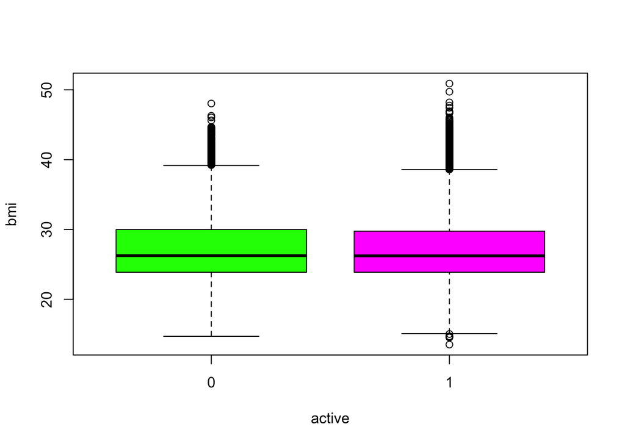

We conclude that no smoking, alcohol consumption, and female gender are contributed to higher BMI. In addition, the discussed characteristics has less impact on BMI among people who are active than people who are not active. Because cardiovascular diseases have correlation with BMI, People who no smoking, drink alcohol, and female gender also be the risk factors of cardiovascular diseases.

## Chapter 5: Age

### 5.1 SMART Question

Are the mean values of different factors such as systolic blood pressure and diastolic blood pressure same across age group?

### 5.2.1 Are systolic blood pressure the same across all age group

We mention age and cardio diseases have relationship. We we discuss about age and bloos pressure.

H0: The mean values of Systolic blood pressure are the same across all agegroup.

H1: The mean values of Systolic blood pressure are different across age groups.

ANOVA and TukeyHSD are used to test the hypothesis and calculate the p-value. The diagram blow summarizes the results.

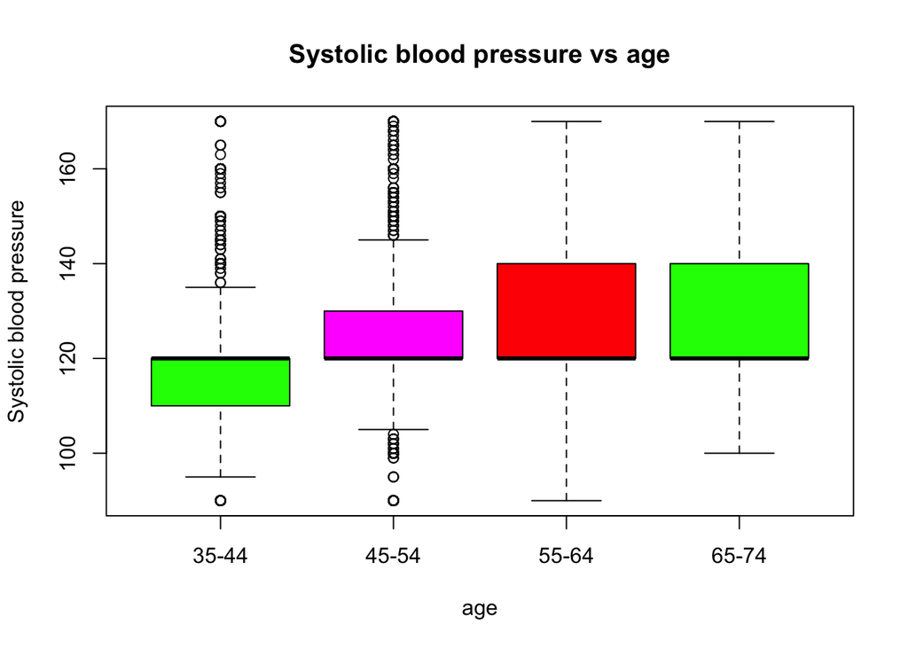

```
##                Df   Sum Sq Mean Sq F value Pr(>F)
## ageGroup        3   454301  151434   769.1 <2e-16 ***
## Residuals   62495 12305612     197
## ---
## Signif. codes:  0 '***' 0.001 '**' 0.01 '*' 0.05 '.' 0.1 ' ' 1
```

```
##   Tukey multiple comparisons of means
##     95% family-wise confidence level
##
## Fit: aov(formula = ap_hi ~ ageGroup, data = cardio)
##
## $ageGroup
##                   diff       lwr      upr     p adj
## 45-54-35-44  4.0170952  3.569310 4.464880 0.0000000
## 55-64-35-44  7.7224200  7.281768 8.163072 0.0000000
## 65-74-35-44  7.5728352  5.527256 9.618414 0.0000000
## 55-64-45-54  3.7053248  3.392737 4.017912 0.0000000
## 65-74-45-54  3.5557400  1.533877 5.577603 0.0000370
## 65-74-55-64 -0.1495848 -2.169880 1.870710 0.9975614
```

### 5.3 Are diastolic blood pressure the same across all age group

H0: The mean values of diastolic blood pressure are the same across all agegroup.

H1: The mean values of diastolic blood pressure are different across age groups.

ANOVA and TukeyHSD are used to test the hypothesis and calculate the p-value. The diagram blow summarizes the results.

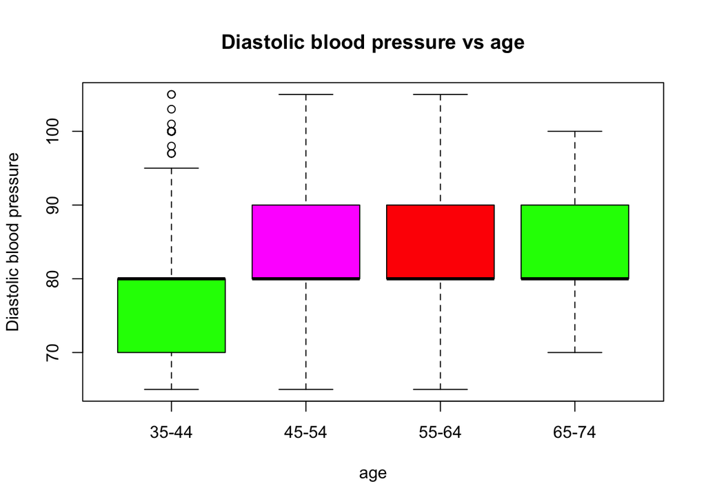

```
##                Df  Sum Sq Mean Sq F value Pr(>F)
## ageGroup        3   70521   23507   407.1 <2e-16 ***
## Residuals   62495 3608599      58
## ---
## Signif. codes:  0 '***' 0.001 '**' 0.01 '*' 0.05 '.' 0.1 ' ' 1
```

```
##   Tukey multiple comparisons of means
##     95% family-wise confidence level
##
## Fit: aov(formula = ap_lo ~ ageGroup, data = cardio)
##
## $ageGroup
##                   diff         lwr       upr     p adj
## 45-54-35-44  1.8768690  1.63438260 2.1193553 0.0000000
## 55-64-35-44  3.1436368  2.90501313 3.3822604 0.0000000
## 65-74-35-44  3.0355532  1.92782310 4.1432833 0.0000000
## 55-64-45-54  1.2667678  1.09749421 1.4360414 0.0000000
## 65-74-45-54  1.1586842  0.06379689 2.2535715 0.0331826
## 65-74-55-64 -0.1080836 -1.20212193 0.9859547 0.9942677
```

We can conclude that age will affect blood pressure. High blood pressure increases the incidence of getting cardiovascular disease.

## Chapter 6: Cardiovascular Disease Prediction Method

Being overweight or obese substantially increases your risk of developing cardiovascular disease. However, researchers don’t always agree which method is best for quantifying whether an individual is “too” overweight. So, this section will analyze if the BMI is the best meacurement at predicting risk.

### 6.1 SMART Question

Is BMI the best measurement at predicting risk in every individual? If not, is there another measurement to help to predict the risk of cardiovascular disease?

### 6.2 Cardio in Different BMI Group

To find the adult weight classification, see which of these BMI ranges the weight falls into:

| BMI | adult weight classification |
| --- | --- |
| [0, 18.5) kg/m^2 | underWeight |
| [18.5, 25) kg/m^2 | normalWeight |
| [25, 30) kg/m^2 | overWeight |
| [30, 35) kg/m^2 | obese |
| [35, 45) kg/m^2 | severelyObese |
| [45, 50) kg/m^2 | morbidlyObese |
| [50, Inf) kg/m^2 | superObese |

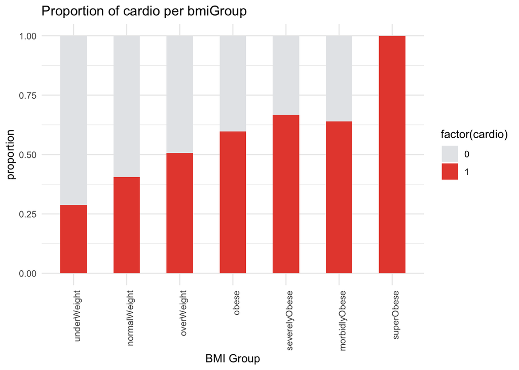

### 6.3 Predicted Waist Circumference by BMI

Carrying excess body fat around your middle is more of a health risk than if weight is on your hips and thighs. In that case, waist circumference is a better estimate of visceral fat, the dangerous internal fat that coats the organs.

An initial model expressed the regression of WC on BMI in the following form:

WCi = b0 + b1BMIi + b2AGEi + b3BLACKi + b4HISPi + ei

where i indexes individuals, WCi is waist circumference for individual i, BMIi is body mass index, AGEi is current age (in years), BLACKi is an indicator for African-American, HISPi is an indicator for Hispanic ethnicity, and ei is the residual.

For women the pattern was better summarized by using one constant for age<35years and a separate intercept and slope for age≥35years. Thus, the model for women was

WCi = c0 + c1BMIi + c2I{AGEi ≥ 35} + c3AGEi × I{AGEi ≥ 35} + c4BLACKi + c5HISPi + ei

where I{B} is an indicator function: I{B} = 1 when B is true and 0 otherwise.

After the prediction, the sample of the data is as follows:

```
##   gender      bmi predict_waist
## 1      2 21.96712      85.90547
## 2      1 34.92768     108.87168
## 3      1 23.50781      83.16440
## 4      2 28.71048     102.58695
## 6      1 29.38468      97.20714
```

### 6.4 Cut Off Line and Obese

Studies have shown that a waist circumference of 95cm or more in men, and of 88cm or more in women, is associated with elevated cardiovascular risk. So, we use these parameters as cuf off line for each gender.

At the same time, two parameters are defined here: “safe area” and “warning area”. When both waist circumference and BMI parameters are lower than the cut off line and obese parameters, the result is safe area, otherwise the result is warnning area.

The statistical results of cardiovascular disease after cut off and obese classification are as follows:

| gender | obese | cut_off | bmi_waist | cardio | n |
| --- | --- | --- | --- | --- | --- |
| 1 | normal weight | below cut off | safe area | 0 | 8920 |
| 1 | normal weight | below cut off | safe area | 1 | 6057 |
| 1 | normal weight | over cut off | warning area | 1 | 2 |
| 1 | obese | below cut off | warning area | 0 | 1285 |
| 1 | obese | below cut off | warning area | 1 | 785 |
| 1 | obese | over cut off | warning area | 0 | 10329 |
| 1 | obese | over cut off | warning area | 1 | 13337 |
| 2 | normal weight | below cut off | safe area | 0 | 5383 |
| 2 | normal weight | below cut off | safe area | 1 | 3579 |
| 2 | normal weight | over cut off | warning area | 0 | 47 |
| 2 | normal weight | over cut off | warning area | 1 | 83 |
| 2 | obese | below cut off | warning area | 0 | 648 |
| 2 | obese | below cut off | warning area | 1 | 376 |
| 2 | obese | over cut off | warning area | 0 | 5019 |
| 2 | obese | over cut off | warning area | 1 | 6649 |

### 6.5 Cut Off Line, Obese, Cardiovascular Disease

- The bar plot below shows the relationship between obesity and cardiovascular disease morbidity in all genders, men and women.

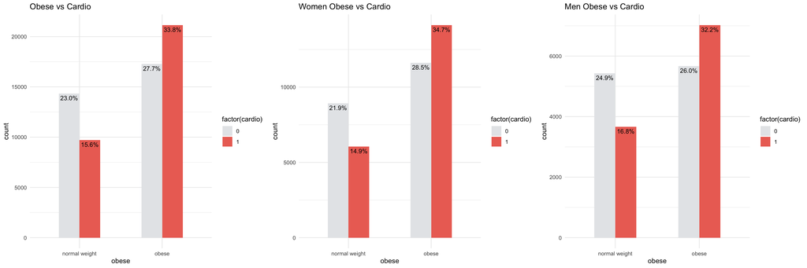

From the three obesity vs cardiovascular disease bar plots, the risk of having cardiovascular disease in all genders is 15.6% if they have normal weight, and 33.8% if they are obese. In only women section, the risk of having cardiovascular disease is 14.9% if she has normal weight, and 34.7% if she is obese. In only men section, the risk of having cardiovascular disease is 16.8% if he has normal weight, and 32.2% if he is obese.

- The bar plot below shows the relationship between cut off line and cardiovascular disease morbidity in all genders, men and women.

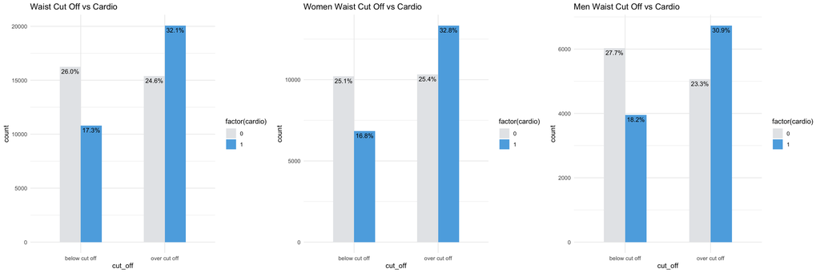

From the three cut off line vs cardiovascular disease bar plots, the risk of having cardiovascular disease in all genders is 17.3% if the waist circumference is below cut off line, and 32.1% if the waist circumference is over cut off line. In only women section, the risk of having cardiovascular disease is 16.8% if her waist circumference is below cut off line, and 32.8% if her waist circumference is over cut off line. In only men section, the risk of having cardiovascular disease is 18.2% if his waist circumference is below cut off line, and 30.9% if his waist circumference is over cut off line.

- The bar plot below shows the relationship between safe/warning area and cardiovascular disease morbidity in all genders, men and women.

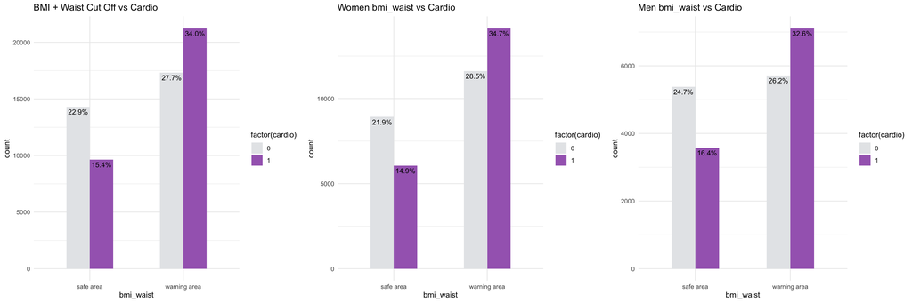

From the three safe/warning area vs cardiovascular disease bar plots, the risk of having cardiovascular disease in all genders is 15.4% if he/she is in safe area, and 34% if he/she is in warning area. In only women section, the risk of having cardiovascular disease is 14.9% if she is in safe area, and 34.7% if she is in warning area. In only men section, the risk of having cardiovascular disease is 16.4% if he is in safe area, and 32.6% if he is in warning area.

### 6.6 Conclusion

- From the three different measurements above (Cut Off Line vs Cardiovascular Disease; Obese vs Cardiovascular Disease; Cut Off Line + Obese vs Cardiovascular Disease), we could see that all of the three measurements work well to help people predict the risk of cardiovascular disease. However, the Cut Off Line + Obese vs Cardiovascular Disease measurement method performs best.
- If you just have your weight and height data and want to predict the disease in an easy way, you can just use them to calculate the BMI value, and use the Obese vs Cardiovascular Disease measurement. Although this method of prediction is not the most accurate in terms of results, it can also be used because the required data is relatively simple and there is no major problem with the overall trend of the prediction results.
- If you want to predict the risk in a more accurate result, you can also measure your waist circumference while measuring your height and weight.

## Chapter 7: Project 1 Conclusion and Discussion

We further subgroup the BMI value into weight classes cataloged by NIH. The plot showed that higher BMI values tend to have an increased risk of cardiovascular disease. Another way to measure in Cardiovascular disease risk is through waist circumference (WC). Abdominal obesity is a well-researched risk factor for CVD and is being suggested to be used in adjunct with BMI to determine a person’s CVD risk. We further predict WC value using a specific formula and set the parameter for plotting (Bozeman et al., 2012), our result indicated that WC value is also a good variable for predicting cardiovascular diseases.

There are many risk factors in Cardiovascular diseases, studies suggested that the genetic variances in patients have an impact on the development of the diseases. Furthermore, a persons’ family with cardiovascular diseases also increased their risk (Kathiresan & Srivastava, 2012). According to Harvard Health Publishing, the rates of high blood pressure, diabetes, and heart disease vary among people of different races and living countries. Therefore, the dataset could include patients’ family background, race, and ethnicity as additional variables for analyzing cardiovascular diseases.

To further analyze the risk factors of cardiovascular disease in next project, we will use the logistic function to analyze the relation between BMI (as numerical data) and other risk factors. Age will be processed as numerical data, rather than categorical, to perform a 2-sample t-test.

The research of this project is quite rewarding, but at the same time it can still be further researched in some aspects, so, on the next project, we will focus more on the direct relationship between unhealthy lifestyles and cardiovascular disease.

## GitHub Link

https://github.com/gggabbby/6101_AceR_MidProject.git

## References:

Benjamin, E. J., Muntner, P., Alonso, A., Bittencourt, M. S., Callaway, C. W., Carson, A. P., . . . Stroke Statistics, S. (2019). Heart Disease and Stroke Statistics-2019 Update: A Report From the American Heart Association. Circulation, 139(10), e56-e528. doi:10.1161/CIR.0000000000000659

Bozeman, S. R., Hoaglin, D. C., Burton, T. M., Pashos, C. L., Ben-Joseph, R. H., & Hollenbeak, C. S. (2012). Predicting waist circumference from body mass index. BMC Med Res Methodol, 12, 115. doi:10.1186/1471-2288-12-115

Cardiovascular Disease [Web log post]. Retrieved Oct 12, 2019, from https://www.who.int/health-topics/cardiovascular-diseases/

Kathiresan, S., & Srivastava, D. (2012). Genetics of human cardiovascular disease. Cell, 148(6), 1242-1257. doi:10.1016/j.cell.2012.03.001